# Variant Nowcast Scoring Simulations

Ben Rogers

2024-09-13

## The Code

Simulation functions:

```r
score <- function(forecast_counts, observed, n){

  es_sample(observed, forecast_counts)

}

# dirichlet_scale controls the width of the forecaster's submission
# n_theta_draws is the number of draws from the posterior forecaster submits
# n is number of observed sequences
# multi_draws is the number of draws from each multinomial distribution.

do_one_replicate <- function(replicate_index,
                             n = 500,
                             multi_draws = 50,
                             theta = c(.1, .3, .6),
                             theta_1 = c(.1, .3, .6),
                             theta_2 = c(.2, .25, .55),
                             dirichlet_scale_1 = 10,
                             dirichlet_scale_2 = 10,
                             n_theta_draws_max = 2000){


  #Sequence of possible requirements for number of draws - we will look at each one
  draw_sizes <- seq(100, n_theta_draws_max, by=100)

  # Sample a draw from a multinomial(n, theta) distribution
  observed <- c(rmultinom(1, n, theta))

  # Group 1 samples
  theta_hat <-  t(rdirichlet(n = n_theta_draws_max, alpha = dirichlet_scale_1 * theta_1))

  # For each dirichlet draw, sample multi_draws multinomial counts
  # Returns K by multi_draws*n_theta_draws_max matrix, where each column is the multiple draws for each theta
  samples <- matrix(c(apply(theta_hat, 2, rmultinom, n=multi_draws, size = n)), nrow=nrow(theta_hat), byrow=F)


  #We take the first S samples from the full theta_hat and score on those
  ES_1 <- purrr::map_dbl(
    draw_sizes,
    function(one_size) {
      score(samples[,1:(one_size*multi_draws)], observed, n)
    })

  # Do the same as above for the group 2, who gets it wrong
  theta_hat <-  t(rdirichlet(n = n_theta_draws_max, alpha = dirichlet_scale_2 * theta_2))

  samples <- matrix(c(apply(theta_hat, 2, rmultinom, n=multi_draws, size = n)), nrow=nrow(theta_hat), byrow=F)

  ES_2 <- purrr::map_dbl(
    draw_sizes,
    function(one_size) {
      score(samples[,1:(one_size*multi_draws)], observed, n)
    })

  results_df = data.frame(draw_sizes, ES_1, ES_2)



  return(results_df)
}



#Run and plot the simulation
run_plot_simulation <- function(n, multi_draws, theta, theta_1, theta_2, dirichlet_scale_1, dirichlet_scale_2, n_theta_draws_max, seed, n_replicates)
{


  #For testing purposes
  # n <- 100
  # multi_draws <- 100
  # theta <- c(.1, .2, .3, .4)
  # wrong_theta <- c(.25, .25, .25, .25)
  # dirichlet_scale <- 10
  # n_theta_draws_max <- 1000
  # seed <- 42

  plan(multisession, workers = 6)


  results <- furrr::future_map(
    seq_len(n_replicates),
    do_one_replicate,
    n = n,
    multi_draws = multi_draws,
    theta = theta,
    theta_1 = theta_1,
    theta_2 = theta_2,
    dirichlet_scale_1 = dirichlet_scale_1,
    dirichlet_scale_2 = dirichlet_scale_2,
    n_theta_draws_max = n_theta_draws_max,
    .progress = TRUE,
    .options = furrr_options(seed = seed)
  )

  results_df <- do.call(rbind, results)

  results_df$rep <- rep(1:n_replicates, each=n_theta_draws_max/100)


  return(results_df)
}
```

## Scenario 1

Two Dirichlet’s centered at the truth, one more certain

```r
sim_1 <- run_plot_simulation(n = 100,
                             multi_draws = 1,
                             theta = c(.1, .2, .3, .4),
                             theta_1 = c(.1,.2,.3,.4),
                             theta_2 = c(.1,.2,.3,.4),
                             dirichlet_scale_1 = 100,
                             dirichlet_scale_2 = 10,
                             n_theta_draws_max = 1000,
                             seed = 23,
                             n_replicates = 200)
```

And plot it:

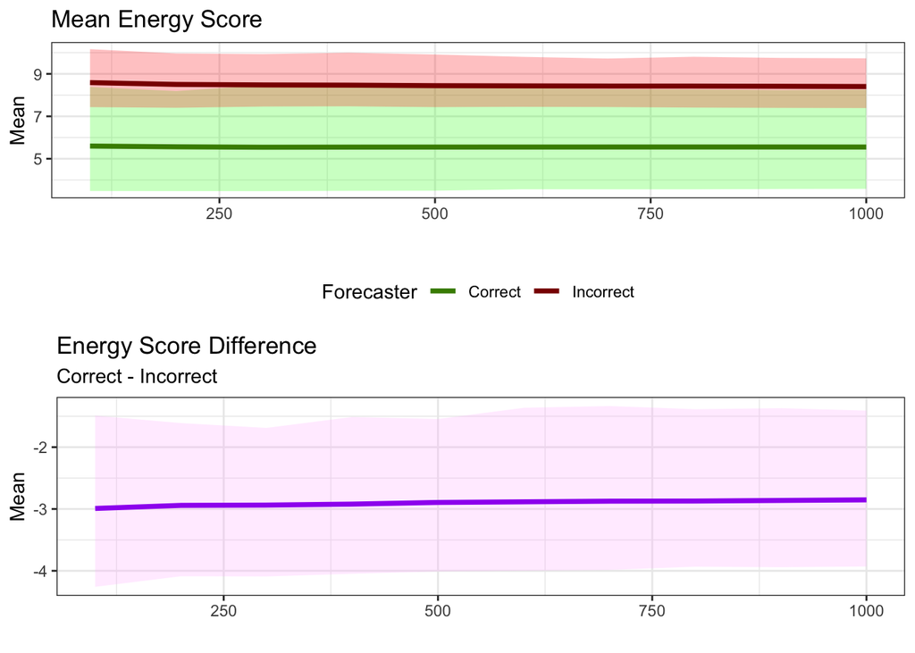

### 10 draws from each sample proportion

```r
start_time <- Sys.time()
sim_1 <- run_plot_simulation(n = 100,
                             multi_draws = 10,
                             theta = c(.1, .2, .3, .4),
                             theta_1 = c(.1,.2,.3,.4),
                             theta_2 = c(.1,.2,.3,.4),
                             dirichlet_scale_1 = 100,
                             dirichlet_scale_2 = 10,
                             n_theta_draws_max = 1000,
                             seed = 23,
                             n_replicates = 200)
```

And plot it:

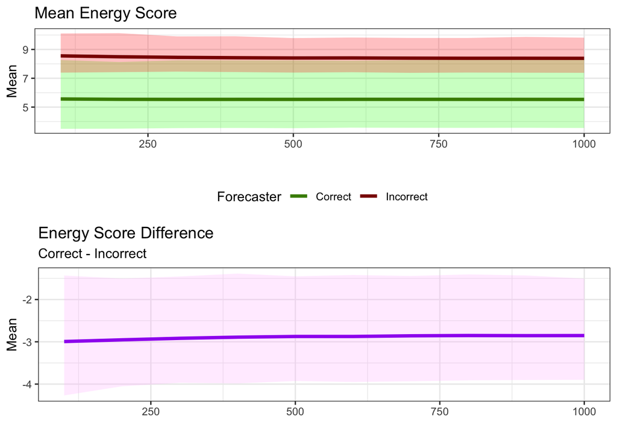

## Scenario 2

Two Dirichlet’s centered at some wrong value, one more certain than the other.

```r
start_time <- Sys.time()
sim_1 <- run_plot_simulation(n = 100,
                             multi_draws = 1,
                             theta = c(.1, .2, .3, .4),
                             theta_1 = c(.2,.2,.3,.3),
                             theta_2 = c(.2,.2,.3,.3),
                             dirichlet_scale_1 = 100,
                             dirichlet_scale_2 = 10,
                             n_theta_draws_max = 1000,
                             seed = 23,
                             n_replicates = 200)
```

```
## Time difference of 1.636786 hours
```

And plot it:

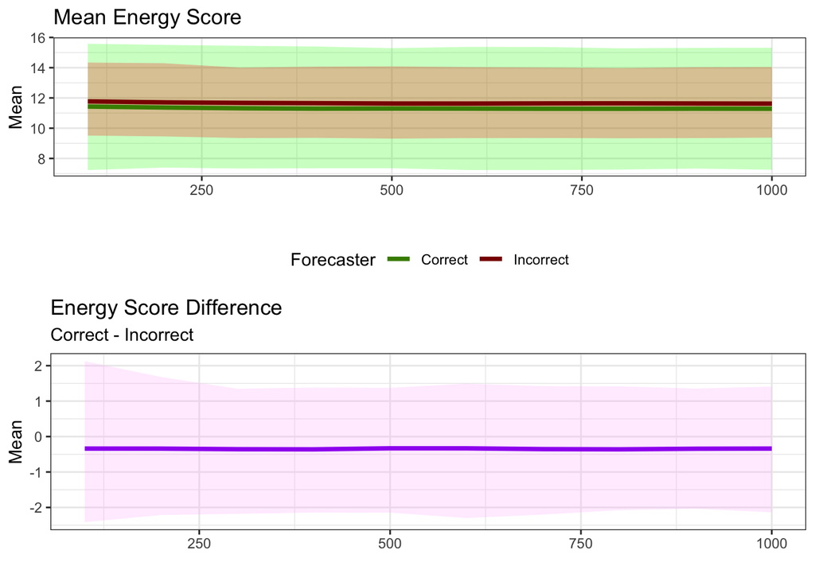

#### 10 draws from each sample proportion

```r
start_time <- Sys.time()
sim_1 <- run_plot_simulation(n = 100,
                             multi_draws = 10,
                             theta = c(.1, .2, .3, .4),
                             theta_1 = c(.2,.2,.3,.3),
                             theta_2 = c(.2,.2,.3,.3),
                             dirichlet_scale_1 = 100,
                             dirichlet_scale_2 = 10,
                             n_theta_draws_max = 1000,
                             seed = 23,
                             n_replicates = 200)
```

```
## Time difference of 1.635742 hours
```

And plot it:

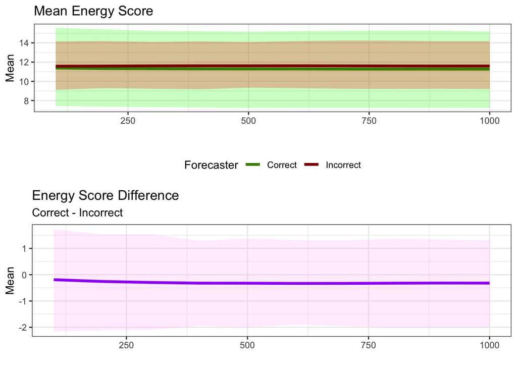

## Scenario 3

Two Dirichlet’s of equal certainty, closer to and farther from the truth

```r
start_time <- Sys.time()
sim_1 <- run_plot_simulation(n = 100,
                             multi_draws = 1,
                             theta = c(.1, .2, .3, .4),
                             theta_1 = c(.2,.2,.3,.3),
                             theta_2 = c(.25,.25,.25,.25),
                             dirichlet_scale_1 = 10,
                             dirichlet_scale_2 = 10,
                             n_theta_draws_max = 1000,
                             seed = 23,
                             n_replicates = 200)
```

```
## Time difference of 1.590034 hours
```

And plot it:

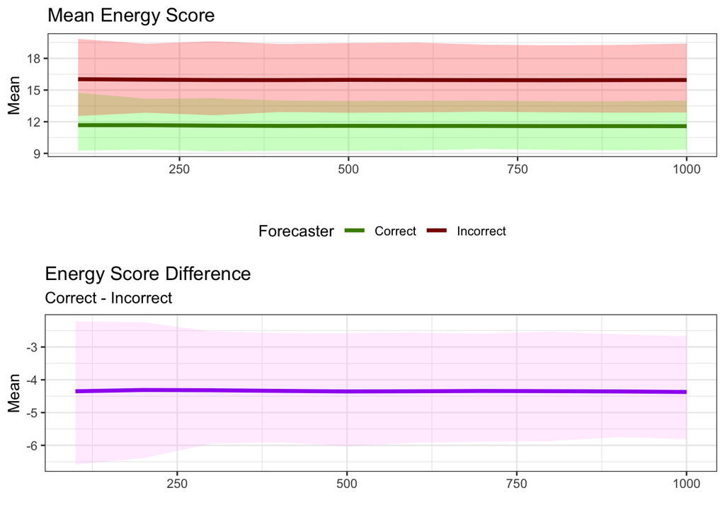

#### 10 draws from each sample proportion

```r
sim_1 <- run_plot_simulation(n = 100,
                             multi_draws = 10,
                             theta = c(.1, .2, .3, .4),
                             theta_1 = c(.2,.2,.3,.3),
                             theta_2 = c(.25,.25,.25,.25),
                             dirichlet_scale_1 = 10,
                             dirichlet_scale_2 = 10,
                             n_theta_draws_max = 1000,
                             seed = 23,
                             n_replicates = 200)
```

And plot it:

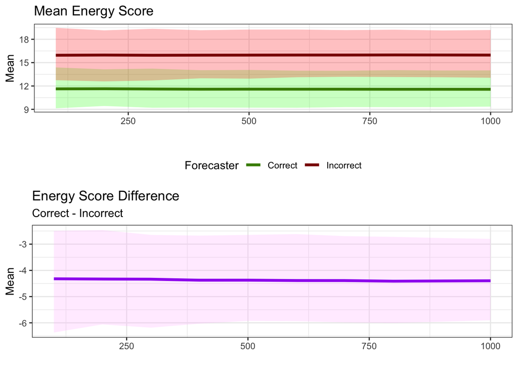

## Scenario 4: 10 Variants

First sample vector:

10 variants, first three proportions are .4, .3, .1, remaining 7 given prob .2 / 7 = 0.02857143 each.

Wrong group incorrectly has a 4th high prevalence variant: c(.4, .3, .1, .19, rep(.01/6, 6)),

```r
sim_1 <- run_plot_simulation(n = 100,
                             multi_draws = 1,
                             theta = c(.4, .3, .1, rep(.2/7 , 7)),
                             theta_1 = c(.4, .3, .1, rep(.2/7 , 7)),
                             theta_2 = c(.4, .3, .1, .19, rep(.01/6, 6)),
                             dirichlet_scale_1 = 10,
                             dirichlet_scale_2 = 10,
                             n_theta_draws_max = 1000,
                             seed = 23,
                             n_replicates = 200)
```

And plot it:

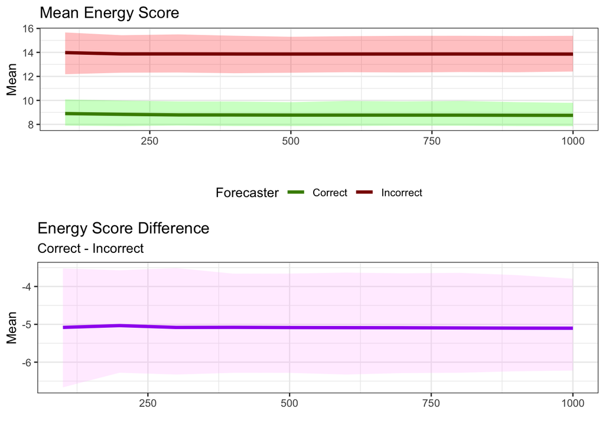

#### 10 draws from each sample proportion

```r
sim_1 <- run_plot_simulation(n = 100,
                             multi_draws = 10,
                             theta = c(.4, .3, .1, rep(.2/7 , 7)),
                             theta_1 = c(.4, .3, .1, rep(.2/7 , 7)),
                             theta_2 = c(.4, .3, .1, .19, rep(.01/6, 6)),
                             dirichlet_scale_1 = 10,
                             dirichlet_scale_2 = 10,
                             n_theta_draws_max = 1000,
                             seed = 23,
                             n_replicates = 200)
```

And plot it:

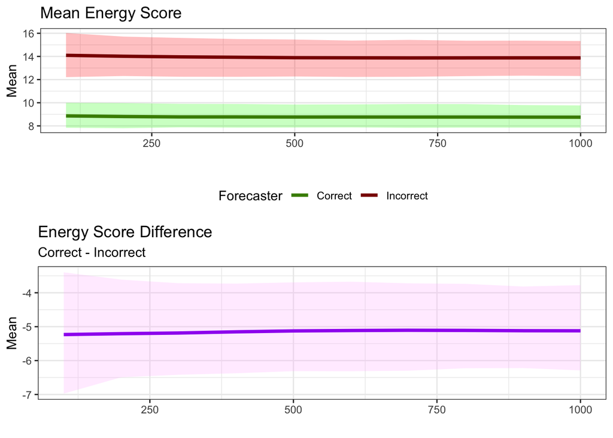

## Scenario 5

10 variants, both groups get proportions correct, but group 2 has wider forecast distribution.

```r
start_time <- Sys.time()
sim_1 <- run_plot_simulation(n = 100,
                             multi_draws = 1,
                             theta = c(.4, .3, .1, rep(.2/7 , 7)),
                             theta_1 = c(.4, .3, .1, rep(.2/7 , 7)),
                             theta_2 = c(.4, .3, .1, rep(.2/7 , 7)),
                             dirichlet_scale_1 = 100,
                             dirichlet_scale_2 = 10,
                             n_theta_draws_max = 1000,
                             seed = 23,
                             n_replicates = 200)
```

And plot it:

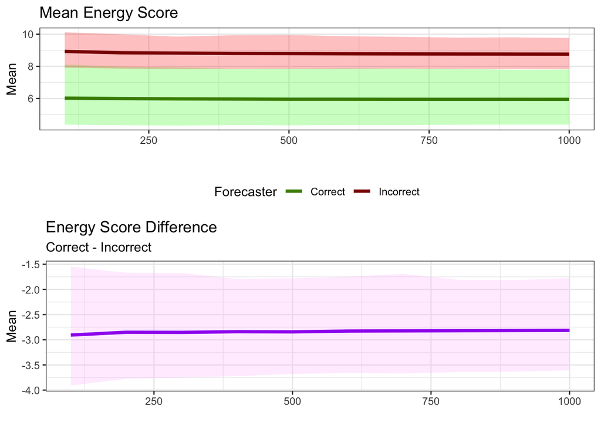

## Scenario 6

10 variant forecast, same scale parameters, group 2 misses on location.

```r
start_time <- Sys.time()
sim_1 <- run_plot_simulation(n = 100,
                             multi_draws = 1,
                             theta = c(.4, .3, .1, rep(.2/7 , 7)),
                             theta_1 = c(.4, .3, .1, rep(.2/7 , 7)),
                             theta_2 = c(.3, .2, .3, rep(.2/7 , 7)),
                             dirichlet_scale_1 = 10,
                             dirichlet_scale_2 = 10,
                             n_theta_draws_max = 1000,
                             seed = 23,
                             n_replicates = 200)
```

And plot it:

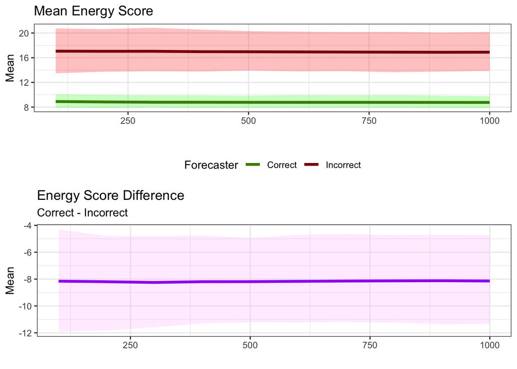

## Now everything with 10 observed samples instead of 100

## Scenario 1

Two Dirichlet’s centered at the truth, one more certain

```r
start_time <- Sys.time()
sim_1 <- run_plot_simulation(n = 10,
                             multi_draws = 1,
                             theta = c(.1, .2, .3, .4),
                             theta_1 = c(.1,.2,.3,.4),
                             theta_2 = c(.1,.2,.3,.4),
                             dirichlet_scale_1 = 100,
                             dirichlet_scale_2 = 10,
                             n_theta_draws_max = 1000,
                             seed = 23,
                             n_replicates = 200)
```

And plot it:

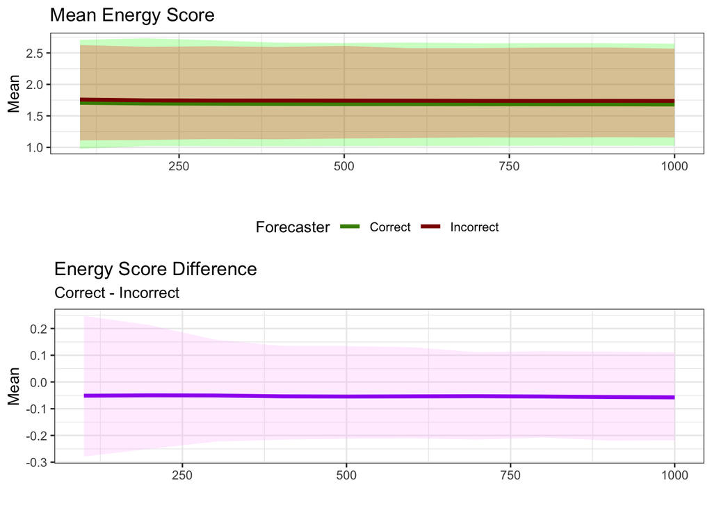

### 10 draws from each sample proportion

```r
start_time <- Sys.time()
sim_1 <- run_plot_simulation(n = 10,
                             multi_draws = 10,
                             theta = c(.1, .2, .3, .4),
                             theta_1 = c(.1,.2,.3,.4),
                             theta_2 = c(.1,.2,.3,.4),
                             dirichlet_scale_1 = 100,
                             dirichlet_scale_2 = 10,
                             n_theta_draws_max = 1000,
                             seed = 23,
                             n_replicates = 200)
```

And plot it:

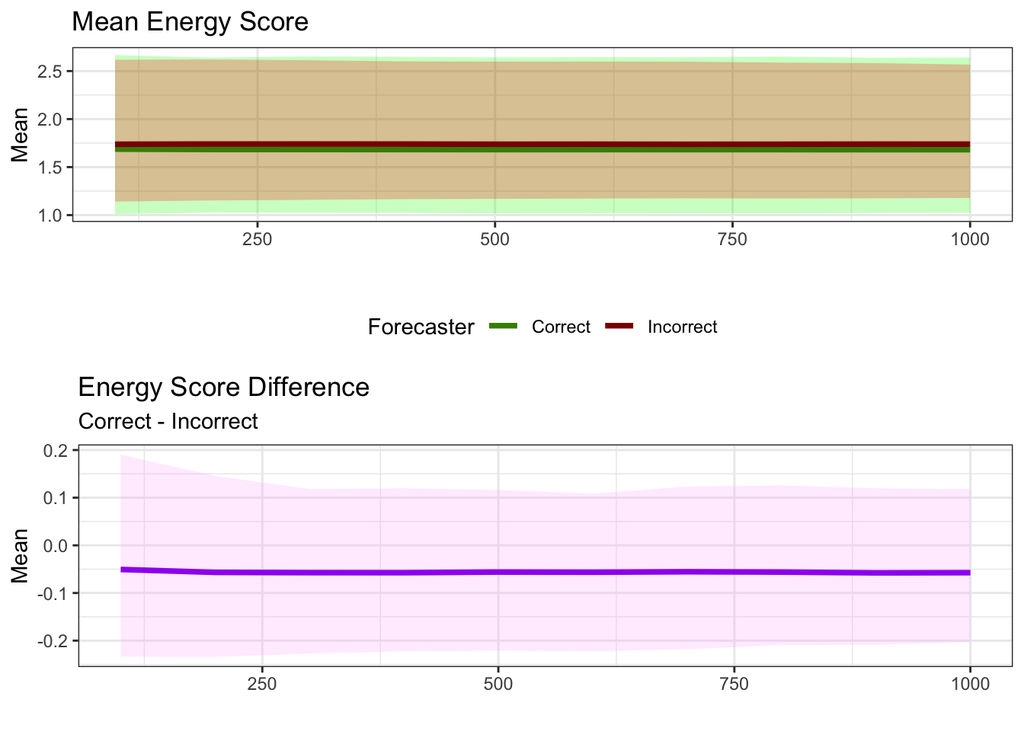

## Scenario 2

Two Dirichlet’s centered at some wrong value, one more certain than the other.

```r
start_time <- Sys.time()
sim_1 <- run_plot_simulation(n = 10,
                             multi_draws = 1,
                             theta = c(.1, .2, .3, .4),
                             theta_1 = c(.2,.2,.3,.3),
                             theta_2 = c(.2,.2,.3,.3),
                             dirichlet_scale_1 = 100,
                             dirichlet_scale_2 = 10,
                             n_theta_draws_max = 1000,
                             seed = 23,
                             n_replicates = 200)
```

And plot it:

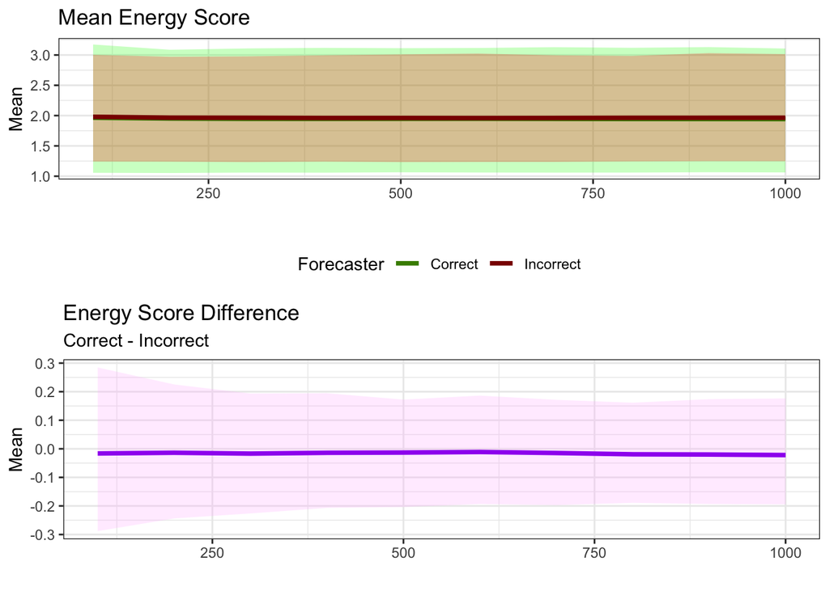

## Scenario 3

Two Dirichlet’s of equal certainty, closer to and farther from the truth

```r
start_time <- Sys.time()
sim_1 <- run_plot_simulation(n = 10,
                             multi_draws = 1,
                             theta = c(.1, .2, .3, .4),
                             theta_1 = c(.2,.2,.3,.3),
                             theta_2 = c(.25,.25,.25,.25),
                             dirichlet_scale_1 = 10,
                             dirichlet_scale_2 = 10,
                             n_theta_draws_max = 1000,
                             seed = 23,
                             n_replicates = 200)
```

And plot it:

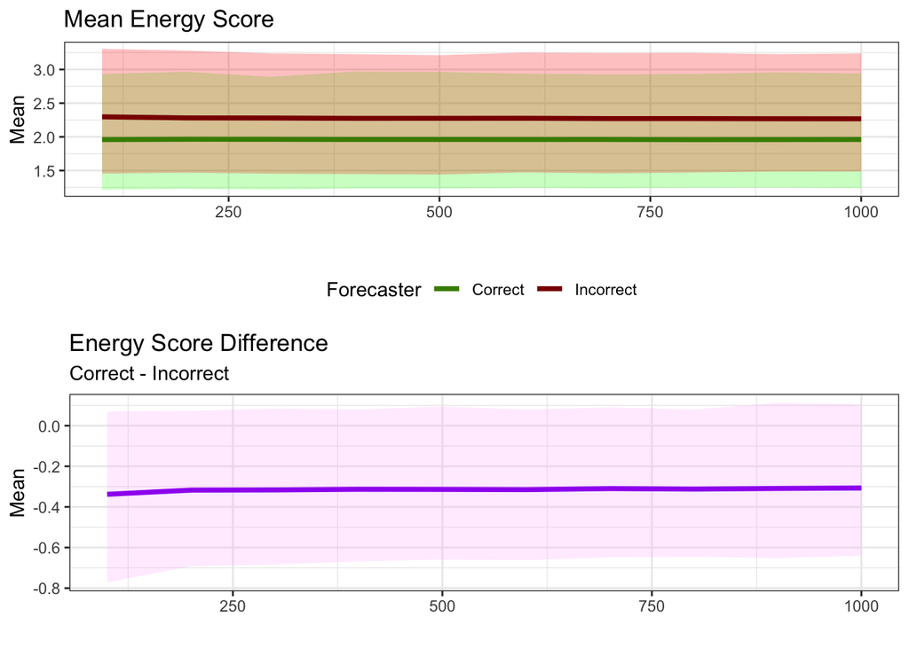

## 10 Variant Question

First sample vector:

10 variants, first three probs are .4 .3 .1, remaining 7 given prob .2 / 7 = 0.02857143 each.

```r
start_time <- Sys.time()
sim_1 <- run_plot_simulation(n = 10,
                             multi_draws = 1,
                             theta = c(.4, .3, .1, rep(.2/7 , 7)),
                             theta_1 = c(.4, .3, .1, rep(.2/7 , 7)),
                             theta_2 = c(.4, .3, .1, .19, rep(.01/6, 6)),
                             dirichlet_scale_1 = 10,
                             dirichlet_scale_2 = 10,
                             n_theta_draws_max = 1000,
                             seed = 23,
                             n_replicates = 200)
```

And plot it:

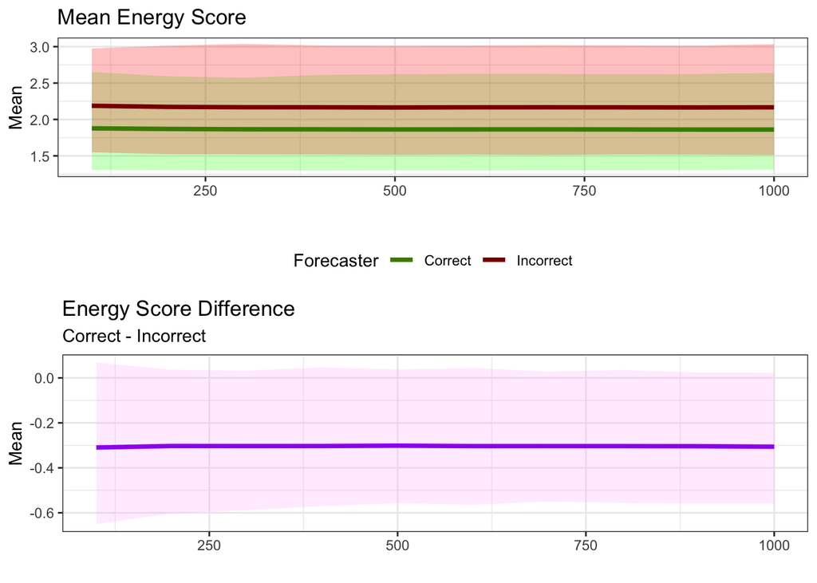

## Scenario 5

```r
start_time <- Sys.time()
sim_1 <- run_plot_simulation(n = 10,
                             multi_draws = 1,
                             theta = c(.4, .3, .1, rep(.2/7 , 7)),
                             theta_1 = c(.4, .3, .1, rep(.2/7 , 7)),
                             theta_2 = c(.4, .3, .1, rep(.2/7 , 7)),
                             dirichlet_scale_1 = 100,
                             dirichlet_scale_2 = 10,
                             n_theta_draws_max = 1000,
                             seed = 23,
                             n_replicates = 200)
```

And plot it:

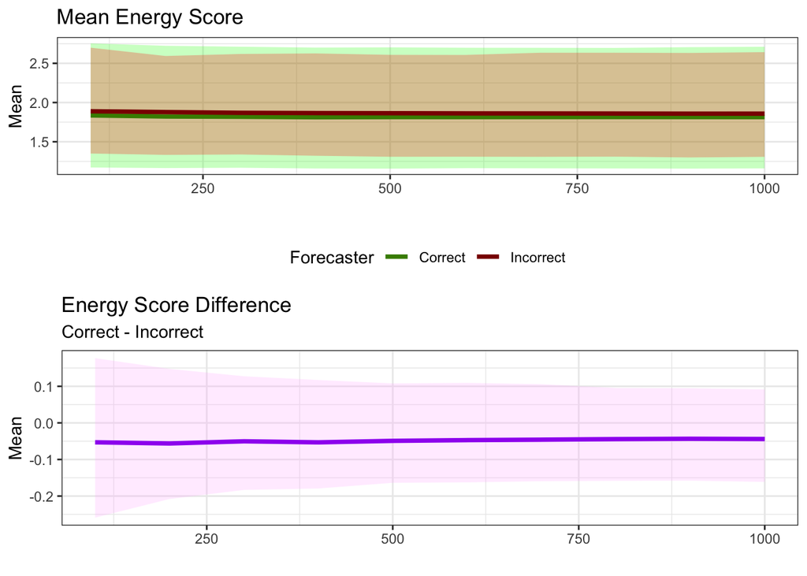

## Scenario 6, n=10

```r
start_time <- Sys.time()
sim_1 <- run_plot_simulation(n = 10,
                             multi_draws = 1,
                             theta = c(.4, .3, .1, rep(.2/7 , 7)),
                             theta_1 = c(.4, .3, .1, rep(.2/7 , 7)),
                             theta_2 = c(.3, .2, .3, rep(.2/7 , 7)),
                             dirichlet_scale_1 = 10,
                             dirichlet_scale_2 = 10,
                             n_theta_draws_max = 1000,
                             seed = 23,
                             n_replicates = 200)
```

And plot it:

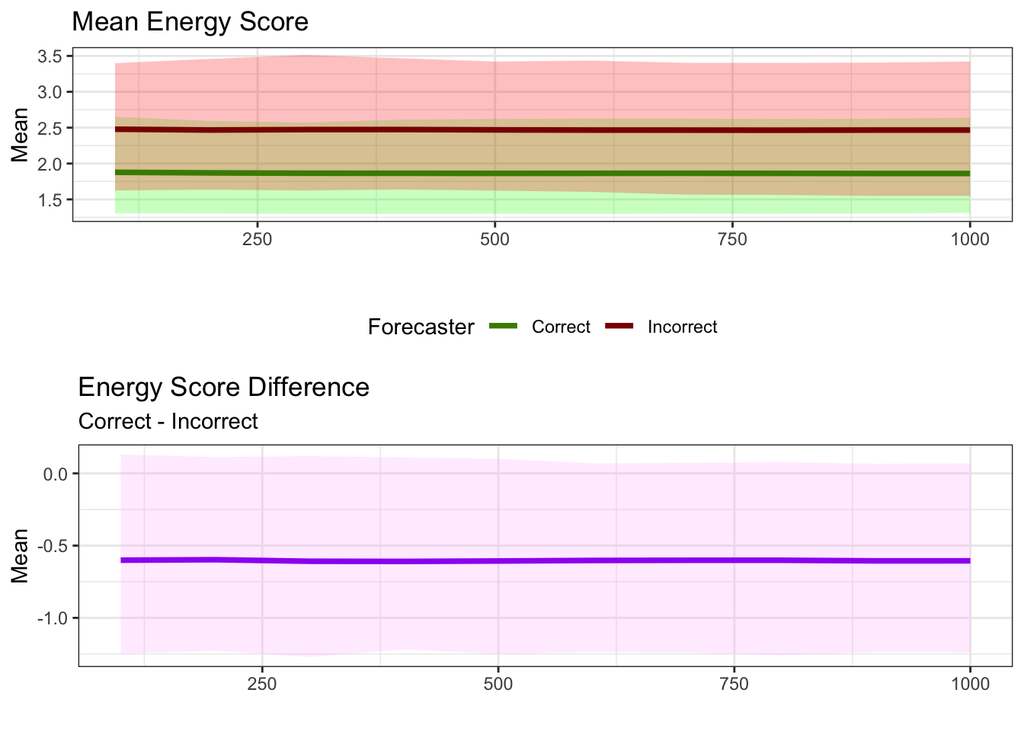